# Тестовое задание

1) Изучить датасет, посмотреть основные статистики по столбцам и все, что может быть интересно при первом знакомстве с данными.  
2) Визуализировать количество персон по датам первого входа (ось X) на графике.  
3) Выбрать клиентов, дата первого входа которых была в 2023 г., затем посмотреть, сколько из них до сих пор пользуются сервисом. Результат дополнительно описать или визуализировать.  
4) Количество устройств на аккаунте – построить график распределения столбца.  
5) Показать количество дней playtrack для разных диапазонов даты первого входа (например, сгруппировать по сезонам – осень 2023, зима 2024 и т.п.).  
6) Посмотреть, какие жанры более популярны, какие менее.

## Общая информация.

```python
import pandas as pd
import numpy as np
import matplotlib.pyplot as plt
import seaborn as sns
import phik
```

### Считываем данные из CSV-файла в датафрейм и сохраняем в переменную df.

```python
df = pd.read_csv('VIP_test_fin.csv', index_col=[0])
```

### Выводим случайные 10 строк таблицы на экран.

```python
df.sample(10)
```

|  | person_id | first_login_dt | last_playtrack_dt | fl_playtrack_day_90d | last_main_screen_dt | cnt_device_day_30d | fl_app_push_on_music | cnt_days_playtrack_day_90d | fl_playtrack30_pop_day_30d | fl_playtrack30_rap_day_30d | fl_playtrack30_dance_day_30d | fl_playtrack30_rock_day_30d | fl_playtrack30_electronics_day_30d |
| --- | --- | --- | --- | --- | --- | --- | --- | --- | --- | --- | --- | --- | --- |
| 554 | pers782643762 | 2022-11-22 | 2024-03-27 | 1.0 | 2024-10-19 | 0.0 | NaN | 30.0 | 0.0 | 0.0 | 0.0 | 1.0 | 0.0 |
| 1884 | pers200179117 | 2024-06-25 | 2024-07-18 | 0.0 | 2024-07-19 | 0.0 | 1.0 | 0.0 | 1.0 | 0.0 | 1.0 | 0.0 | 0.0 |
| 1848 | pers814277055 | 2022-11-21 | 2023-06-28 | 1.0 | 2024-09-14 | 0.0 | NaN | 0.0 | 0.0 | 0.0 | 1.0 | 0.0 | 0.0 |
| 263 | pers538885100 | 2024-08-27 | 2024-10-02 | 1.0 | 2024-10-19 | 1.0 | NaN | 50.0 | 0.0 | 0.0 | 0.0 | 1.0 | 1.0 |
| 1343 | pers152169660 | 2022-12-29 | 2023-10-04 | 1.0 | 2024-06-06 | 0.0 | 1.0 | 0.0 | 1.0 | 1.0 | 0.0 | 0.0 | 0.0 |
| 769 | pers772454374 | 2022-11-26 | NaN | 0.0 | 2024-10-15 | 0.0 | 0.0 | 47.0 | 1.0 | 1.0 | 1.0 | 0.0 | 0.0 |
| 8 | pers655401986 | 2023-07-15 | 2024-08-23 | 0.0 | 2024-10-02 | 0.0 | NaN | 0.0 | 0.0 | 0.0 | 0.0 | 0.0 | 0.0 |
| 442 | pers648863827 | NaN | 2024-07-27 | 0.0 | 2023-06-03 | 0.0 | 0.0 | 49.0 | 0.0 | 1.0 | 1.0 | 0.0 | 0.0 |
| 1005 | pers091738409 | 2022-11-01 | NaN | 0.0 | NaN | 0.0 | 0.0 | 0.0 | 0.0 | 0.0 | 0.0 | 1.0 | 1.0 |
| 1054 | pers391616695 | 2024-09-09 | NaN | 0.0 | 2024-09-14 | 1.0 | 0.0 | 2.0 | 0.0 | 0.0 | 0.0 | 0.0 | 0.0 |

Описание данных:

1. `person_id` - ID персоны
2. `first_login_dt` - Дата первого входа в сервис
3. `last_playtrack_dt`- Дата последнего `playtrack`
4. `fl_playtrack_day_90d` - Флаг `playtrack` 90d
5. `last_main_screen_dt` - Дата последнего просмотра главного экрана
6. `cnt_device_day_30d` - Количество устройств на аккаунте 30d
7. `fl_app_push_on_music` - Флаг включенных push-уведомлений МТС Музыка
8. `cnt_days_playtrack30_day_90d` - Количество дней `playtrack` более 30 секунд 90d
9. `fl_playtrack30_pop_day_30d` - Флаг `playtrack` более 30 секунд жанра `pop` 30d
10. `fl_playtrack30_rap_day_30d` - Флаг `playtrack` более 30 секунд жанра `rap` 30d
11. `fl_playtrack30_dance_day_30d` - Флаг `playtrack` более 30 секунд жанра `dance` 30d
12. `fl_playtrack30_rock_day_30d` - Флаг `playtrack` более 30 секунд жанра `rock` 30d
13. `fl_playtrack30_electronics_day_30d` - Флаг `playtrack` более 30 секунд жанра `electronics` 30d

### Выводим информацию о датафрейме с помощью метода describe().

```python
df.describe(include='all')
```

|  | person_id | first_login_dt | last_playtrack_dt | fl_playtrack_day_90d | last_main_screen_dt | cnt_device_day_30d | fl_app_push_on_music | cnt_days_playtrack_day_90d | fl_playtrack30_pop_day_30d | fl_playtrack30_rap_day_30d | fl_playtrack30_dance_day_30d | fl_playtrack30_rock_day_30d | fl_playtrack30_electronics_day_30d |
| --- | --- | --- | --- | --- | --- | --- | --- | --- | --- | --- | --- | --- | --- |
| count | 2459 | 2362 | 1995 | 2440.000000 | 2158 | 2438.000000 | 1420.000000 | 2442.000000 | 2441.000000 | 2430.000000 | 2437.000000 | 2434.00000 | 2437.000000 |
| unique | 2074 | 580 | 460 | NaN | 493 | NaN | NaN | NaN | NaN | NaN | NaN | NaN | NaN |
| top | pers122316032 | 2022-11-01 | 2024-10-19 | NaN | 2024-10-19 | NaN | NaN | NaN | NaN | NaN | NaN | NaN | NaN |
| freq | 2 | 157 | 285 | NaN | 248 | NaN | NaN | NaN | NaN | NaN | NaN | NaN | NaN |
| mean | NaN | NaN | NaN | 0.405328 | NaN | 0.359311 | 0.547887 | 10.262899 | 0.238017 | 0.188477 | 0.196143 | 0.20378 | 0.194091 |
| std | NaN | NaN | NaN | 0.491056 | NaN | 0.481604 | 0.497877 | 21.108537 | 0.425957 | 0.391173 | 0.397159 | 0.40289 | 0.395581 |
| min | NaN | NaN | NaN | 0.000000 | NaN | 0.000000 | 0.000000 | 0.000000 | 0.000000 | 0.000000 | 0.000000 | 0.00000 | 0.000000 |
| 25% | NaN | NaN | NaN | 0.000000 | NaN | 0.000000 | 0.000000 | 0.000000 | 0.000000 | 0.000000 | 0.000000 | 0.00000 | 0.000000 |
| 50% | NaN | NaN | NaN | 0.000000 | NaN | 0.000000 | 1.000000 | 0.000000 | 0.000000 | 0.000000 | 0.000000 | 0.00000 | 0.000000 |
| 75% | NaN | NaN | NaN | 1.000000 | NaN | 1.000000 | 1.000000 | 6.000000 | 0.000000 | 0.000000 | 0.000000 | 0.00000 | 0.000000 |
| max | NaN | NaN | NaN | 1.000000 | NaN | 2.000000 | 1.000000 | 88.000000 | 1.000000 | 1.000000 | 1.000000 | 1.00000 | 1.000000 |

**Замечание:** Здесь можно увидеть информацию о входных данных по столбцам (например максимальное и минимальное значение признака).

### Построим общую гистограмму для всех числовых столбцов таблицы.

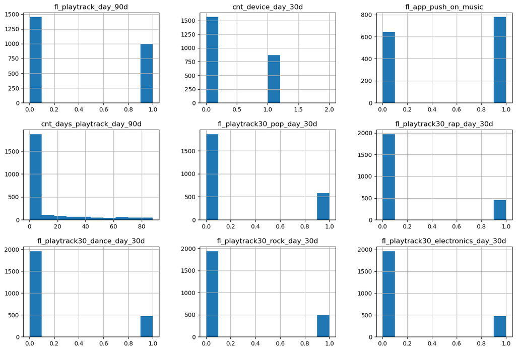

```python
df.hist(figsize=(15,10));
```

**Замечание:** Гистограммы наглядно представляют как распределяются значения.

### Выводим основную информацию о датафрейме с помощью метода info().

```python
df.info()
```

```
<class 'pandas.core.frame.DataFrame'>
Int64Index: 2459 entries, 0 to 2458
Data columns (total 13 columns):
 #   Column                              Non-Null Count  Dtype
---  ------                              --------------  -----
 0   person_id                           2459 non-null   object
 1   first_login_dt                      2362 non-null   object
 2   last_playtrack_dt                   1995 non-null   object
 3   fl_playtrack_day_90d                2440 non-null   float64
 4   last_main_screen_dt                 2158 non-null   object
 5   cnt_device_day_30d                  2438 non-null   float64
 6   fl_app_push_on_music                1420 non-null   float64
 7   cnt_days_playtrack_day_90d          2442 non-null   float64
 8   fl_playtrack30_pop_day_30d          2441 non-null   float64
 9   fl_playtrack30_rap_day_30d          2430 non-null   float64
 10  fl_playtrack30_dance_day_30d        2437 non-null   float64
 11  fl_playtrack30_rock_day_30d         2434 non-null   float64
 12  fl_playtrack30_electronics_day_30d  2437 non-null   float64
dtypes: float64(9), object(4)
memory usage: 269.0+ KB
```

**Замечание:** С помощью этой команды видны тип данных таблицы, а также количество записей без пропусков.

### Преобразуем типы данных.

```python
# Удаление подстроки "pers" из id полбзователя и преобразование в формат целого числа для удобства
df['person_id'] = df['person_id'].str.replace('pers', '').astype('int')
# Преобразование столбцов в формат даты
df['first_login_dt'] = pd.to_datetime(df['first_login_dt'], format='%Y-%m-%d', errors='ignore')
df['last_playtrack_dt'] = pd.to_datetime(df['last_playtrack_dt'], format='%Y-%m-%d', errors='ignore')
df['last_main_screen_dt'] = pd.to_datetime(df['last_main_screen_dt'], format='%Y-%m-%d', errors='ignore')
df.info()
```

```
<class 'pandas.core.frame.DataFrame'>
Int64Index: 2459 entries, 0 to 2458
Data columns (total 13 columns):
 #   Column                              Non-Null Count  Dtype
---  ------                              --------------  -----
 0   person_id                           2459 non-null   int32
 1   first_login_dt                      2362 non-null   datetime64[ns]
 2   last_playtrack_dt                   1995 non-null   datetime64[ns]
 3   fl_playtrack_day_90d                2440 non-null   float64
 4   last_main_screen_dt                 2158 non-null   datetime64[ns]
 5   cnt_device_day_30d                  2438 non-null   float64
 6   fl_app_push_on_music                1420 non-null   float64
 7   cnt_days_playtrack_day_90d          2442 non-null   float64
 8   fl_playtrack30_pop_day_30d          2441 non-null   float64
 9   fl_playtrack30_rap_day_30d          2430 non-null   float64
 10  fl_playtrack30_dance_day_30d        2437 non-null   float64
 11  fl_playtrack30_rock_day_30d         2434 non-null   float64
 12  fl_playtrack30_electronics_day_30d  2437 non-null   float64
dtypes: datetime64[ns](3), float64(9), int32(1)
memory usage: 259.3 KB
```

### Проверим датафрейм на наличие явных дубликатов.

```python
df.duplicated().sum()
```

```
0
```

**Замечание:** Дубликатов не обнаружено.

### Исследуем данные на адекватность.

```python
df[df['last_playtrack_dt'] <  df['first_login_dt']]
```

|  | person_id | first_login_dt | last_playtrack_dt | fl_playtrack_day_90d | last_main_screen_dt | cnt_device_day_30d | fl_app_push_on_music | cnt_days_playtrack_day_90d | fl_playtrack30_pop_day_30d | fl_playtrack30_rap_day_30d | fl_playtrack30_dance_day_30d | fl_playtrack30_rock_day_30d | fl_playtrack30_electronics_day_30d |
| --- | --- | --- | --- | --- | --- | --- | --- | --- | --- | --- | --- | --- | --- |
| 6 | 856102166 | 2024-04-13 | 2023-03-08 | 0.0 | NaT | 0.0 | 1.0 | 18.0 | 0.0 | 1.0 | 0.0 | 1.0 | 0.0 |
| 20 | 164620376 | 2024-08-10 | 2024-07-05 | 0.0 | 2023-12-16 | 0.0 | 0.0 | 1.0 | 0.0 | 0.0 | 0.0 | 1.0 | 0.0 |
| 22 | 857835164 | 2024-09-22 | 2023-12-10 | 0.0 | 2024-08-27 | 0.0 | 1.0 | 0.0 | 0.0 | 0.0 | 0.0 | 0.0 | 0.0 |
| 30 | 154674929 | 2024-05-16 | 2023-07-25 | 1.0 | 2024-10-06 | 1.0 | 1.0 | 0.0 | 0.0 | 1.0 | 0.0 | 0.0 | 0.0 |
| 42 | 787897311 | 2024-09-24 | 2023-04-17 | 0.0 | 2023-09-01 | 1.0 | NaN | 0.0 | 0.0 | 0.0 | 0.0 | 0.0 | 0.0 |
| ... | ... | ... | ... | ... | ... | ... | ... | ... | ... | ... | ... | ... | ... |
| 2453 | 254967595 | 2024-04-23 | 2024-03-24 | 0.0 | 2023-01-23 | 1.0 | 0.0 | 0.0 | 0.0 | 1.0 | 0.0 | 0.0 | 0.0 |
| 2454 | 522433067 | 2022-11-09 | 2022-11-01 | 1.0 | 2023-03-14 | 0.0 | 1.0 | 4.0 | 1.0 | 0.0 | 0.0 | 0.0 | 0.0 |
| 2455 | 602852424 | 2023-12-17 | 2023-06-10 | 0.0 | 2024-10-19 | 1.0 | 0.0 | 24.0 | 0.0 | 0.0 | 0.0 | 0.0 | 1.0 |
| 2456 | 239350271 | 2024-03-22 | 2022-12-11 | 0.0 | 2023-12-26 | 1.0 | 1.0 | 60.0 | 1.0 | 0.0 | 0.0 | 0.0 | NaN |
| 2457 | 808276086 | 2024-09-21 | 2023-11-21 | 1.0 | 2024-10-12 | 1.0 | 1.0 | 61.0 | 1.0 | 0.0 | 0.0 | 0.0 | 1.0 |

417 rows × 13 columns

**Замечание:** Мы видим 417 строк, где дата первого входа в сервис идет после даты последнего прослушивания трека. Это странно, возможно стоит не учитывать эти данные в дальнейшем анализе. К вариант, попробуем удалить эти строки. Вести анализ будем с двумя таблицами.

```python
# Сохранение датасета с "адекватными" данными
df_clear = df[df['last_playtrack_dt'] >= df['first_login_dt']]
```

### Проверим как взаимосвязаны признаки с помощью корреляции.

С помощью корреляции `Пирсона` можно оценить числовые признаки, но для категориальных более подходит метод `phik`.

```python
# Функция вывода таблицы корреляции в виде тепловой карты
def corr_plot(data, corr_type):
    '''
    data - таблица с данными
    corr_type - тип корреляции ('pirson' или 'phik')
    '''
    if corr_type == 'pirson':
        table = data.corr()
    if corr_type == 'phik':
        table = data.phik_matrix(verbose=False)
    #mask = np.triu(table, k=1);
    plt.figure(figsize=(20, 15));
    sns.heatmap(table,
                square=True,
                annot=True,
                linewidth=0.5,
                cmap='coolwarm',
                #mask=mask
               );
```

```
None
None
```

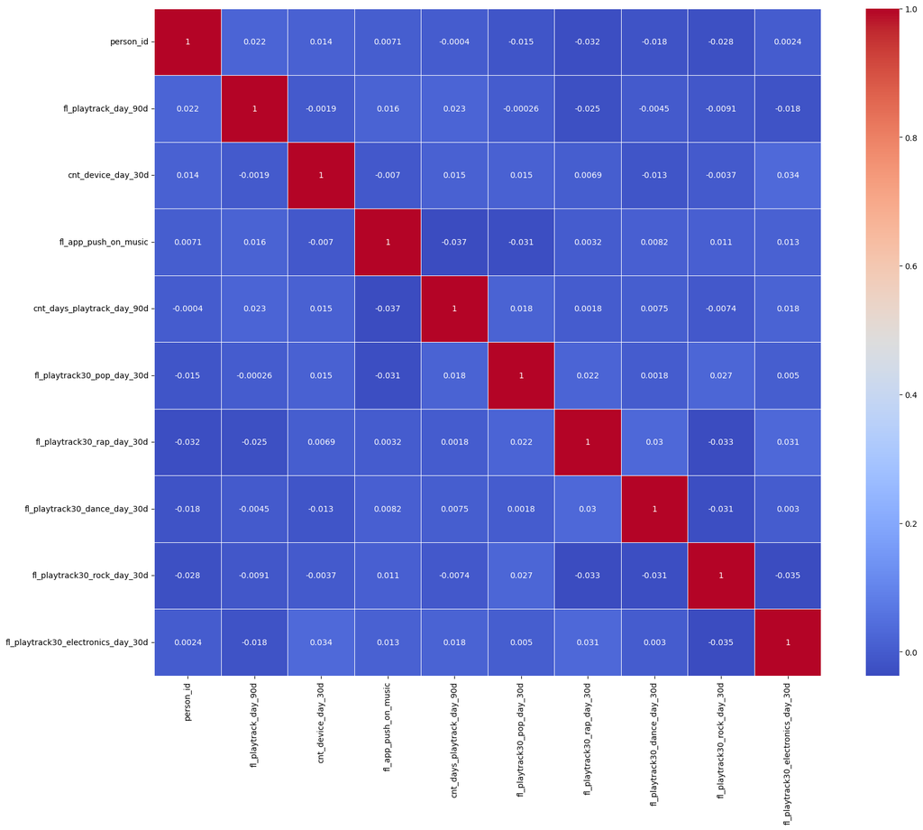

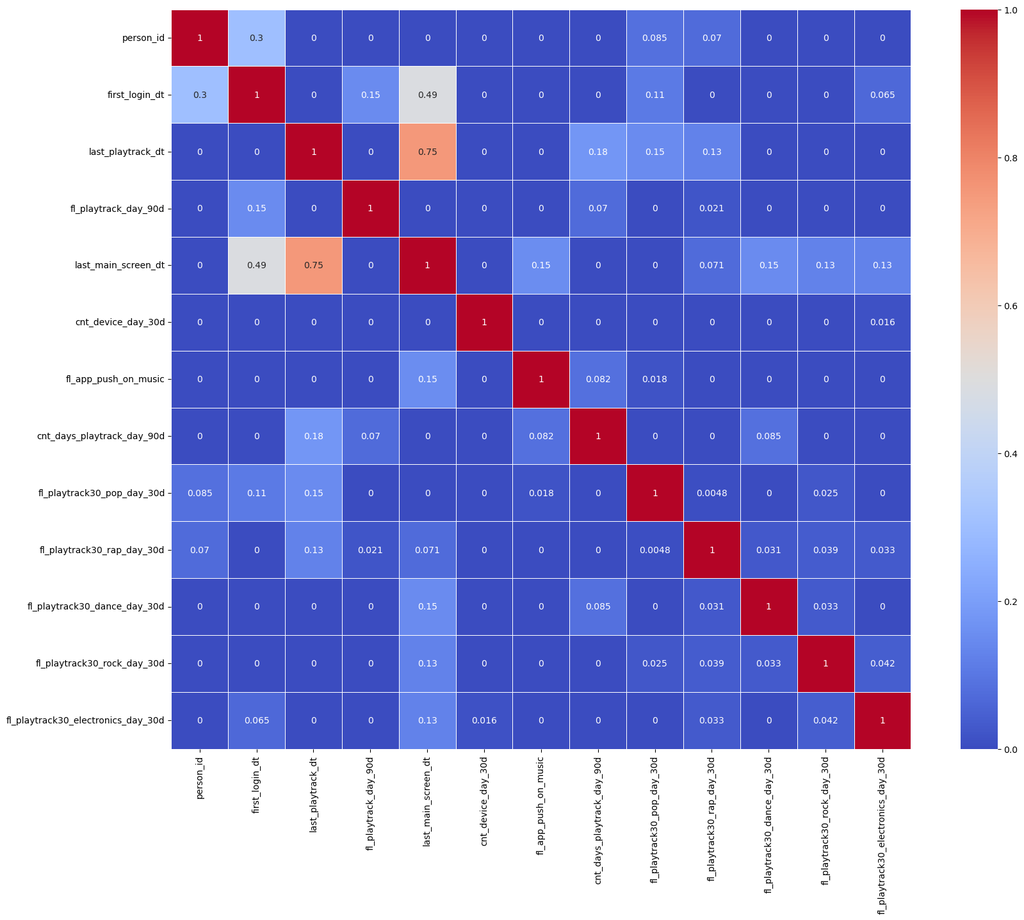

```python
# Вывод корреляции для исходных данных
print(corr_plot(df, 'pirson'))
print(corr_plot(df, 'phik'))
```

```
None
None
```

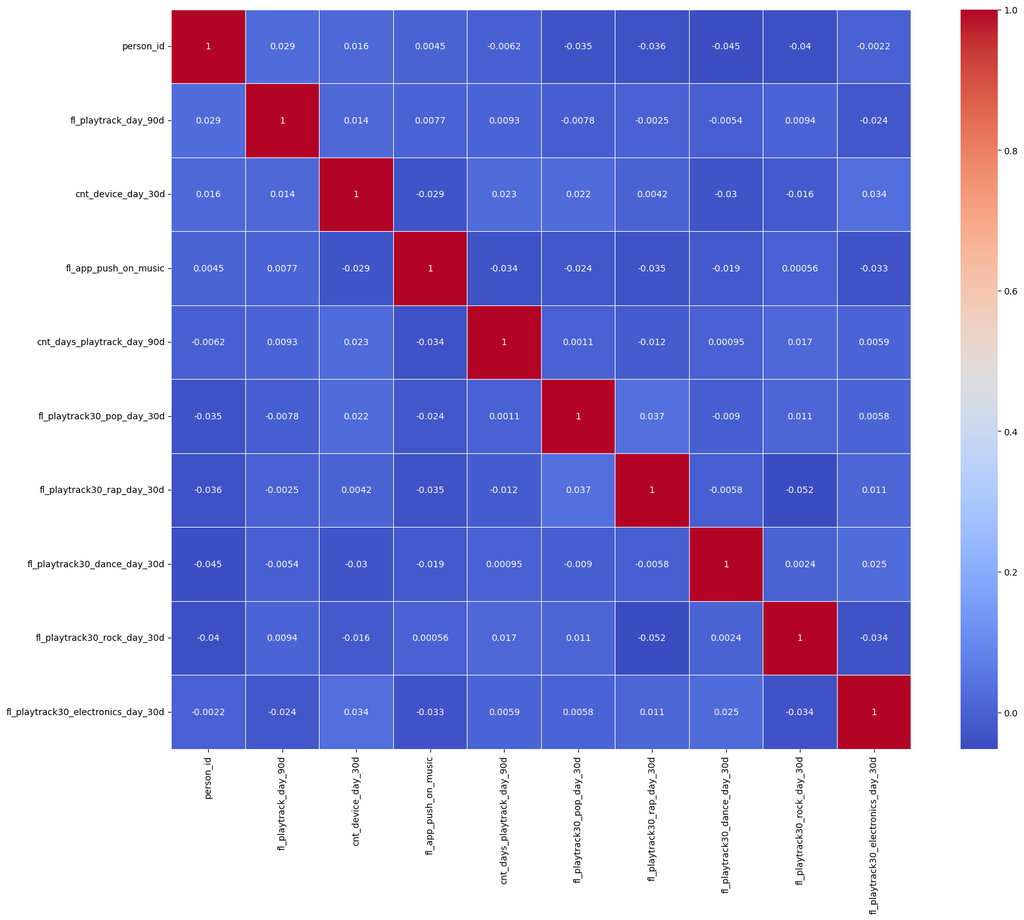

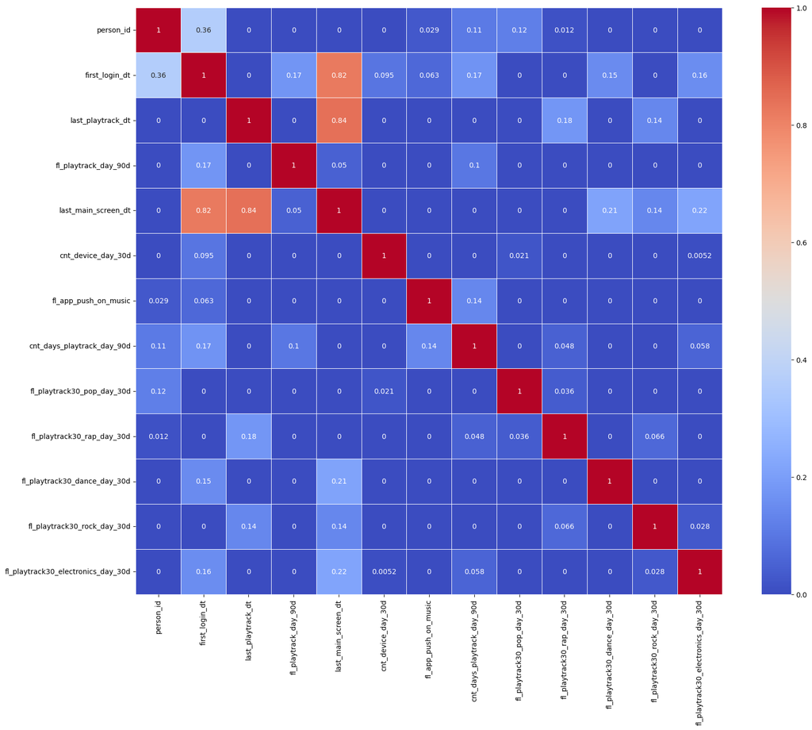

```python
# Вывод корреляции для очищенных данных
print(corr_plot(df_clear, 'pirson'))
print(corr_plot(df_clear, 'phik'))
```

**Замечание:** На графиках видно, что даты регистрации и последнего прослушивания треков с последним входом коррелируют. При этом на "очищенных" данных корреляция более выражена.

### Обработаем пропуски в данных.

```python
# Вывод количества пропущенных данных
df.isna().sum()
```

```
person_id                                0
first_login_dt                          97
last_playtrack_dt                      464
fl_playtrack_day_90d                    19
last_main_screen_dt                    301
cnt_device_day_30d                      21
fl_app_push_on_music                  1039
cnt_days_playtrack_day_90d              17
fl_playtrack30_pop_day_30d              18
fl_playtrack30_rap_day_30d              29
fl_playtrack30_dance_day_30d            22
fl_playtrack30_rock_day_30d             25
fl_playtrack30_electronics_day_30d      22
dtype: int64
```

**Замечание:** Далее сначала заполним пропуски в данных заглушкой. Там где возможно, для очищенного датасета, попробуем заполнить пропущенные значения.

```python
# Заполнение пропусков заглушкой
df_no_info = df.fillna('no_info')
```

**Замечание:** Заполнили пропуски в исходном датасете в данных заглушкой 'no_info'.

```python
# Создание копии датасета
df_filled = df_clear.copy()
```

```python
df_filled[df_filled['first_login_dt'].isna()] = df_clear['first_login_dt'].min()
df_filled[df_filled['last_playtrack_dt'].isna()] = df_clear['last_playtrack_dt'].max()
df_filled[df_filled['last_main_screen_dt'].isna()] = df_clear['last_main_screen_dt'].max()
```

**Замечание:** Здесь предположили, что даты первого входа в сервис пропущенны из-за того, что эти пользователи зарегистрировались раньше исследуемого интервала времени. Даты последнего прослушивания треков и последнего просмотра экрана пропущенны потому что пользователи не перестали пользоваться услугами сервиса.

```python
# Заполнение пропусков заглушкой
df_filled = df_filled.fillna('no_info')
```

## Визуализация количества персон по датам первого входа (ось X) на графике.

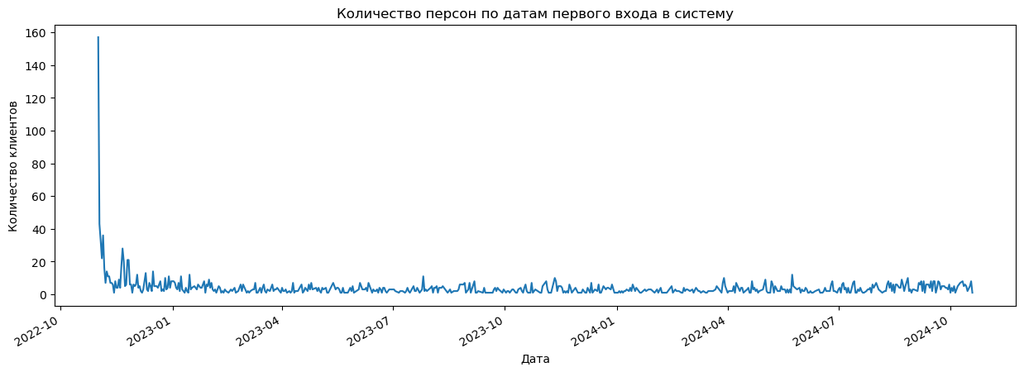

```python
# Визуализация исходных данных
df['first_login_dt'].value_counts().plot(figsize=(15,5)).set_title('Количество персон по датам первого входа в систему')
plt.xlabel('Дата')
plt.ylabel('Количество клиентов');
```

```python
df_no_info['first_login_dt'].value_counts(ascending=False)
```

```
2022-11-01 00:00:00    157
no_info                 97
2022-11-02 00:00:00     43
2022-11-05 00:00:00     36
2022-11-03 00:00:00     33
                      ...
2024-02-23 00:00:00      1
2024-03-04 00:00:00      1
2024-09-10 00:00:00      1
2024-07-11 00:00:00      1
2023-09-18 00:00:00      1
Name: first_login_dt, Length: 581, dtype: int64
```

**Замечание:** Обратим внимание на то что 97 строк были изначально с пропусками.

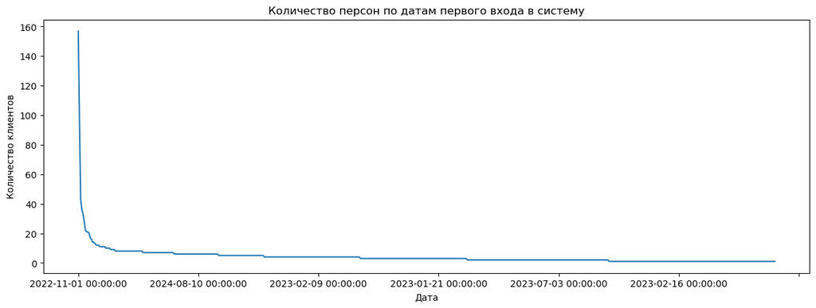

```python
# Визуализация заполненных "заглушкой" данных
df_no_info['first_login_dt'].value_counts().plot(figsize=(15,5)).set_title('Количество персон по датам первого входа в систему')
plt.xlabel('Дата')
plt.ylabel('Количество клиентов');
```

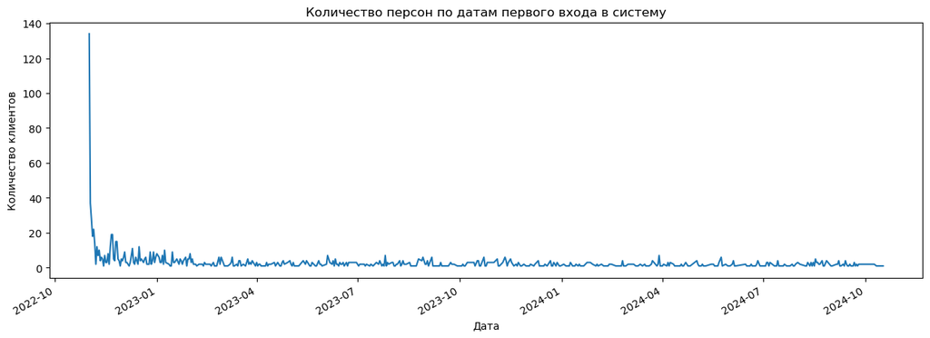

```python
# Визуализация "очищенных" данных
df_clear['first_login_dt'].value_counts().plot(figsize=(15,5)).set_title('Количество персон по датам первого входа в систему')
plt.xlabel('Дата')
plt.ylabel('Количество клиентов');
```

**Замечание:** далее будем рассматривать только исходные (не очищенные) данные.

## Выберем клиентов, дата первого входа которых была в 2023 г., затем посмотрим, сколько из них до сих пор пользуются сервисом.

```python
# Визуализация "очищенных" данных
df[df['first_login_dt'].dt.year == 2023]
```

|  | person_id | first_login_dt | last_playtrack_dt | fl_playtrack_day_90d | last_main_screen_dt | cnt_device_day_30d | fl_app_push_on_music | cnt_days_playtrack_day_90d | fl_playtrack30_pop_day_30d | fl_playtrack30_rap_day_30d | fl_playtrack30_dance_day_30d | fl_playtrack30_rock_day_30d | fl_playtrack30_electronics_day_30d |
| --- | --- | --- | --- | --- | --- | --- | --- | --- | --- | --- | --- | --- | --- |
| 0 | 195918153 | 2023-02-09 | 2024-05-08 | 0.0 | 2023-04-24 | 0.0 | 1.0 | 1.0 | 0.0 | 0.0 | 0.0 | NaN | 0.0 |
| 1 | 612132512 | 2023-06-18 | 2024-10-17 | 0.0 | 2024-06-28 | 0.0 | 1.0 | 0.0 | 0.0 | 0.0 | 0.0 | 0.0 | 0.0 |
| 3 | 720630892 | 2023-06-12 | 2023-08-09 | 0.0 | 2024-05-04 | 1.0 | 0.0 | 0.0 | 1.0 | 0.0 | 1.0 | 0.0 | 1.0 |
| 4 | 752255130 | 2023-07-07 | 2024-10-11 | 1.0 | 2024-10-18 | 0.0 | NaN | 38.0 | 0.0 | 0.0 | 0.0 | 0.0 | 0.0 |
| 8 | 655401986 | 2023-07-15 | 2024-08-23 | 0.0 | 2024-10-02 | 0.0 | NaN | 0.0 | 0.0 | 0.0 | 0.0 | 0.0 | 0.0 |
| ... | ... | ... | ... | ... | ... | ... | ... | ... | ... | ... | ... | ... | ... |
| 2439 | 27874534 | 2023-01-13 | 2024-08-19 | 0.0 | 2024-09-11 | 0.0 | 0.0 | 0.0 | 1.0 | 1.0 | 0.0 | 0.0 | 0.0 |
| 2441 | 845517238 | 2023-05-15 | 2024-10-17 | 1.0 | 2024-10-19 | 1.0 | NaN | 0.0 | 0.0 | 0.0 | 0.0 | 0.0 | 0.0 |
| 2444 | 497137561 | 2023-09-18 | 2024-10-09 | 1.0 | 2024-10-18 | 1.0 | 1.0 | 0.0 | 1.0 | 0.0 | 0.0 | 0.0 | 0.0 |
| 2448 | 259051241 | 2023-11-24 | 2024-09-23 | 0.0 | 2024-10-18 | 0.0 | 1.0 | 9.0 | 1.0 | 1.0 | 1.0 | 0.0 | 0.0 |
| 2455 | 602852424 | 2023-12-17 | 2023-06-10 | 0.0 | 2024-10-19 | 1.0 | 0.0 | 24.0 | 0.0 | 0.0 | 0.0 | 0.0 | 1.0 |

877 rows × 13 columns

**Замечание:** Предположим, что у тех кто зарегистрировался в 2023 году и пользуется сервисом до сих пор, дата последнего просмотра экрана максимальная.

```python
len(df[(df['first_login_dt'].dt.year == 2023) & (df['last_main_screen_dt'] == df['last_main_screen_dt'].max())])
```

```
94
```

**Замечание:** Мы видим количество пользователей которые зарегистрировались в 2023 году и пользуются сервисом до сих пор равно 94.

## Выясним количество устройств на аккаунте.

```python
df['cnt_device_day_30d'].value_counts()
```

```
0.0    1564
1.0     872
2.0       2
Name: cnt_device_day_30d, dtype: int64
```

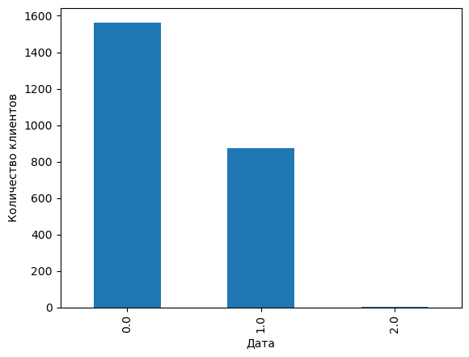

```python
df['cnt_device_day_30d'].value_counts().plot.bar()
plt.xlabel('Дата')
plt.ylabel('Количество клиентов');
```

**Замечание:** Заметим что у большинства пользователей количество устройств равно 0, что очень странно.

```python
seasons = [1, 1, 2, 2, 2, 3, 3, 3, 4, 4, 4, 1]
month_to_season = dict(zip(range(1,13), seasons))
df['season'] = df['first_login_dt'].dt.month.map(month_to_season)
df['year'] = df['first_login_dt'].dt.year
df.groupby(['year','season']).count()['first_login_dt']
```

```
year    season
2022.0  1.0       172
        4.0       537
2023.0  1.0       271
        2.0       194
        3.0       222
        4.0       190
2024.0  1.0        98
        2.0       210
        3.0       263
        4.0       205
Name: first_login_dt, dtype: int64
```

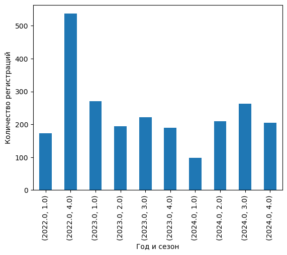

```python
df.groupby(['year','season']).count()['first_login_dt'].plot.bar()
plt.xlabel('Год и сезон')
plt.ylabel('Количество регистраций');
```

## Посмотрим, какие жанры более популярны, какие менее.

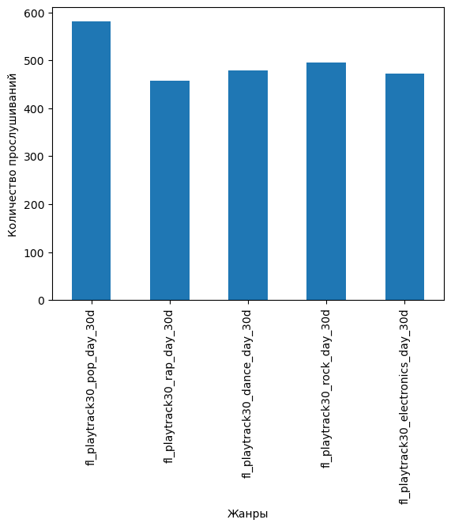

```python
df[['fl_playtrack30_pop_day_30d',
    'fl_playtrack30_rap_day_30d',
    'fl_playtrack30_dance_day_30d',
    'fl_playtrack30_rock_day_30d',
    'fl_playtrack30_electronics_day_30d']].sum().plot.bar()
plt.xlabel('Жанры')
plt.ylabel('Количество прослушиваний');
```

**Замечание:** Самый популярный жанр у пользователей сервиса судя по данным `pop` музыка.